# DX 601 Final Project

## Introduction

In this project, you will practice all the skills that you have learned throughout this module. You will pick a data set to analyze from a list provided, and then perform a variety of analysis. Most of the problems and questions are open ended compared to your previous homeworks, and you will be asked to explain your choices. Most of them will have a particular type of solution implied, but it is up to you to figure out the details based on what you have learned in this module.

## Instructions

Each problem asks you to perform some analysis of the data, and usually answer some questions about the results. Make sure that your question answers are well supported by your analysis and explanations; simply stating an answer without support will earn minimal points.

Notebook cells for code and text have been added for your convenience, but feel free to add additional cells.

## Submission

To submit your homework, take the following steps.

1. Save and commit this notebook.
2. Push your changes to GitHub.
3. Confirm that your changes are visible in GitHub.
4. Delete the codespace to avoid wasting your free quota.

This project will be entirely manually graded. However, we may rerun some or all of your code to confirm that it works as described.

## Shared Imports

For this project, you are forbidden to use modules that were not loaded in this template. While other modules are handy in practice, modules that trivialize these problems interfere with our assessment of your own knowledge and skills.

If you believe a module covered in the course material (not live sessions) is missing, please check with your learning facilitator.

```python
import math
import sys
```

```python
import matplotlib.pyplot as plt
import numpy as np
import pandas as pd
import scipy.stats
import sklearn.linear_model
```

## Problems

### Problem 1 (5 points)

Pick one of the following data sets to analyze in this project. Load the data set, and show a random sample of 10 rows.

- [Iris data set](https://archive.ics.uci.edu/dataset/53/iris) ([PMLB copy](https://github.com/EpistasisLab/pmlb/tree/master/datasets/iris))
- [Breast Cancer Wisconsin](https://archive.ics.uci.edu/dataset/17/breast+cancer+wisconsin+diagnostic) ([PMLB copy](https://github.com/EpistasisLab/pmlb/tree/master/datasets/breast_cancer_wisconsin))
- [Wine Quality](https://archive.ics.uci.edu/dataset/186/wine+quality) ([PMLB - white subset only](https://github.com/EpistasisLab/pmlb/tree/master/datasets/wine_quality_white))

The PMLB copies of the data are generally cleaner and recommended for this project, but the other links are provided to give you more context. To load the data from the PMLB Github repository, navigate to the `.tsv.gz` file in GitHub and copy the link from the "Raw" button.

If the data set you choose has more than ten columns, you may limit later analysis that is requested per column to just the first ten columns.

```python
df=pd.read_csv('wine_quality_white.tsv.gz',sep='\t', compression= 'gzip')
df.sample(10)
```

|  | fixed acidity | volatile acidity | citric acid | residual sugar | chlorides | free sulfur dioxide | total sulfur dioxide | density | pH | sulphates | alcohol | target |
| --- | --- | --- | --- | --- | --- | --- | --- | --- | --- | --- | --- | --- |
| 418 | 7.4 | 0.210 | 0.27 | 1.20 | 0.041 | 27.0 | 99.0 | 0.99270 | 3.19 | 0.33 | 9.8 | 6 |
| 847 | 9.2 | 0.340 | 0.27 | 1.20 | 0.026 | 17.0 | 73.0 | 0.99210 | 3.08 | 0.39 | 10.8 | 5 |
| 3104 | 7.6 | 0.210 | 0.49 | 2.50 | 0.047 | 20.0 | 130.0 | 0.99178 | 3.15 | 0.48 | 11.1 | 5 |
| 309 | 6.2 | 0.310 | 0.26 | 4.80 | 0.037 | 36.0 | 148.0 | 0.99280 | 3.21 | 0.41 | 10.4 | 6 |
| 4699 | 6.8 | 0.300 | 0.33 | 12.80 | 0.041 | 60.0 | 168.0 | 0.99659 | 3.10 | 0.56 | 9.8 | 5 |
| 2850 | 6.7 | 0.240 | 0.29 | 14.90 | 0.053 | 55.0 | 136.0 | 0.99839 | 3.03 | 0.52 | 9.0 | 5 |
| 3014 | 7.0 | 0.450 | 0.34 | 19.80 | 0.040 | 12.0 | 67.0 | 0.99760 | 3.07 | 0.38 | 11.0 | 6 |
| 1782 | 8.5 | 0.210 | 0.26 | 9.25 | 0.034 | 73.0 | 142.0 | 0.99450 | 3.05 | 0.37 | 11.4 | 6 |
| 3941 | 4.9 | 0.345 | 0.34 | 1.00 | 0.068 | 32.0 | 143.0 | 0.99138 | 3.24 | 0.40 | 10.1 | 5 |
| 4195 | 7.1 | 0.450 | 0.24 | 2.70 | 0.040 | 24.0 | 87.0 | 0.98862 | 2.94 | 0.38 | 13.4 | 8 |

### Problem 2 (10 points)

List all the columns in the data set, and describe each of them in your own words. You may have to search to learn about the data set columns, but make sure that the descriptions are your own words.

```python
df.columns
```

```
Index(['fixed acidity', 'volatile acidity', 'citric acid', 'residual sugar',
       'chlorides', 'free sulfur dioxide', 'total sulfur dioxide', 'density',
       'pH', 'sulphates', 'alcohol', 'target'],
      dtype='object')
```

- Fixed Acidity: The amount of acid that doesn't evaporate when it's exposed to the air.
- Volatility Acidity: The amount od acetic acid, vinigar like acid, in the wine which is volatile and evaporates easily.
- Citric Acids: A natural organic acid found in grapes
- residual sugar: The sugar that remains in the wine after fermentation which is expressed in grams/liter
- Chlorides: the amount of salt in the wine (g/L)
- Free sulfer duoxide: measures the concentration of free sulfer dioxide and it help prevent oxidation. (g/L)
- Total sulfer dioxide: This measure the anount of sulfer dioxide in the wine (mg/L).
- Density: measures the mass per unit volume of the wine which affects the rischness or heavyness of the wine (g/cm^3)
- pH: measures the wine's acidity on a scale of 0-14.
- Sulphates: measures the concentration of sulfate ions (g/L)
- Alcohol: measures the alcohol content (% vol)
- Quallity: score that is subjectivly assigned to the wine from a range of 1-10. 10 indicating better wine quality.

### Problem 3 (15 points)

Plot histograms of each column. For each column, state the distribution covered in this module that you think best matches that column.

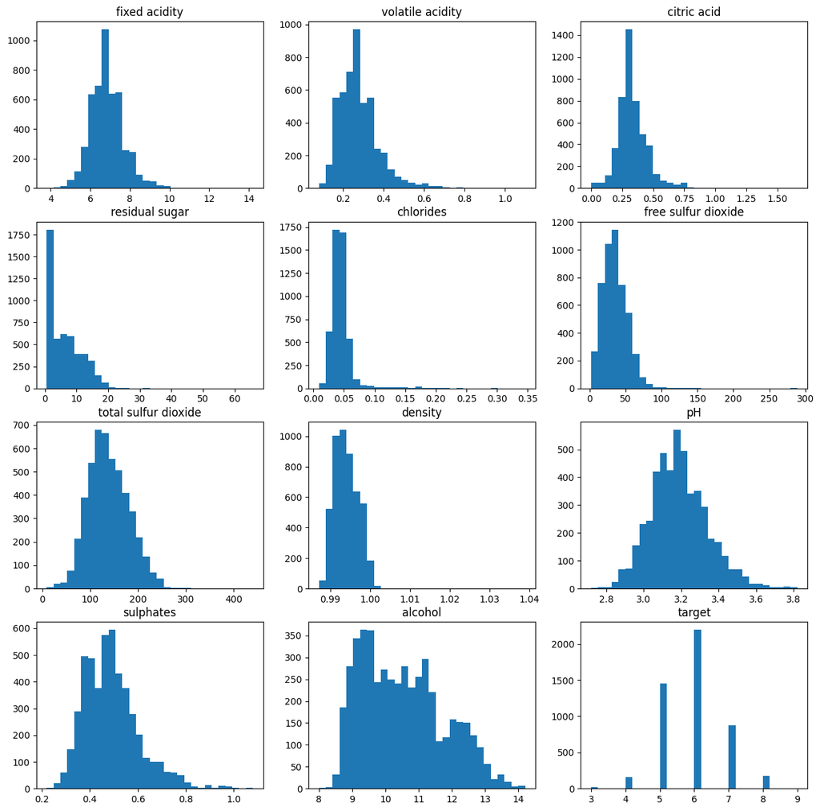

```python
plt.figure(figsize=(15,15))
for i,c in enumerate(df.columns):
    plt.subplot(4,3, i+1)
    df[c].hist(grid=False, bins=30)
    plt.title(c)
```

### Problem 4 (20 points)

Plot each pair of an input column and the output column. Classify each pair of input column and the output column as being independent or not. Describe in words why you think that was the case.

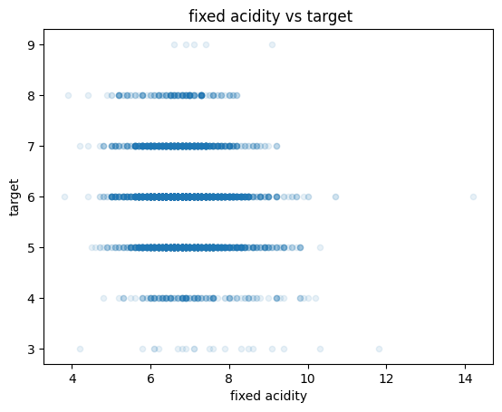

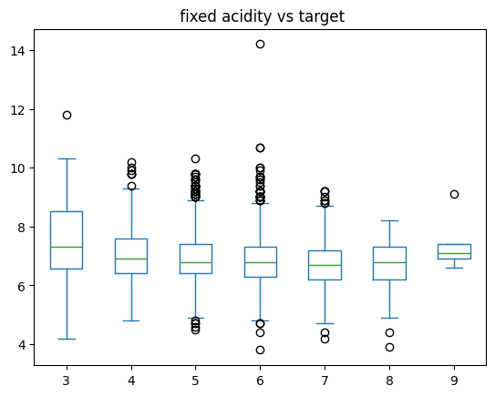

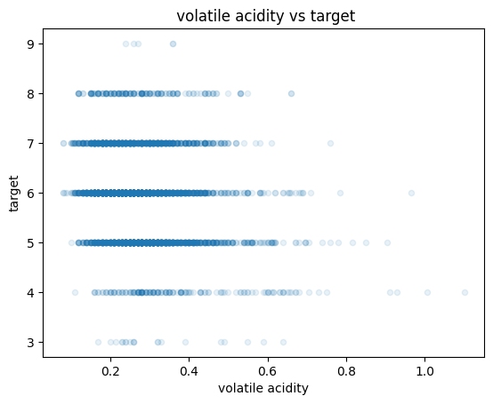

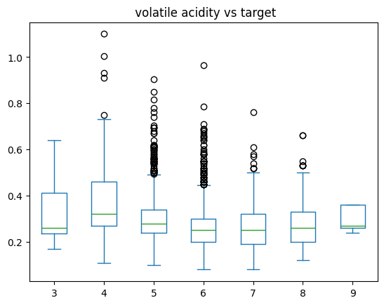

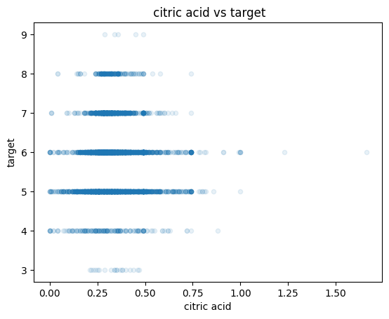

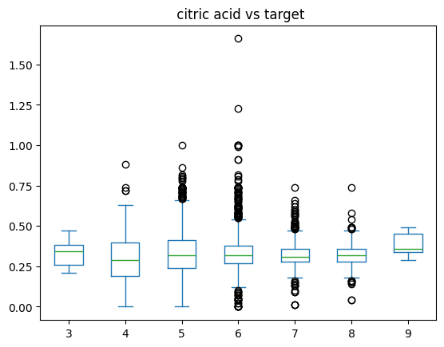

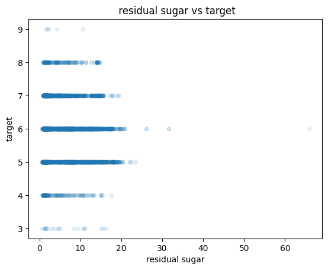

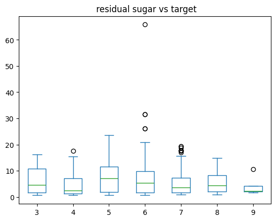

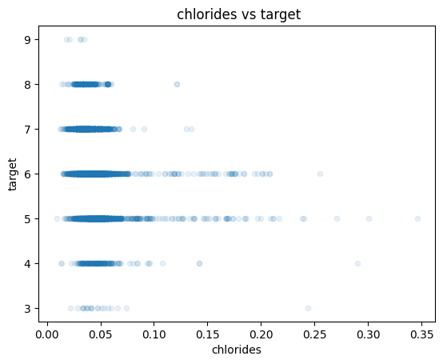

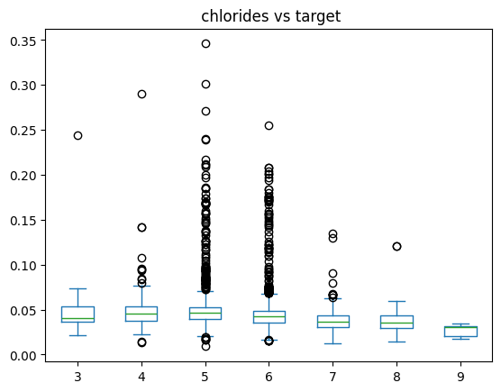

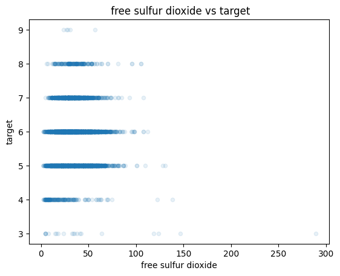

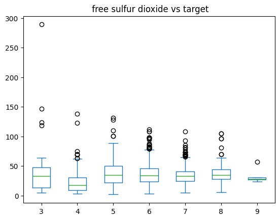

[10 more figures not shown]

```python
#lt.figure(figsize=(20,20))

for c in df.columns.drop('target'):
    df.plot.scatter(c, 'target', alpha=.1)
    plt.title(f" {c} vs target")
    df.plot.box(column=c, by='target')
    plt.title(f" {c} vs target")
```

### Problem 5 (20 points)

Build an ordinary least squares regression for the target using all the input columns. Report the average loss of the model over the whole data set. Plot the actual values vs the predicted outputs to compare them.

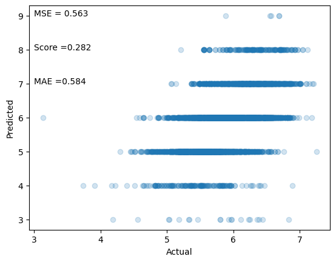

```python
from sklearn.linear_model import LinearRegression
from sklearn.metrics import mean_squared_error
from sklearn.metrics import mean_absolute_error

x=df.drop('target', axis=1)
y= df['target']
model=LinearRegression()
model.fit(x,y)
y_pred=model.predict(x)
mse=round(mean_squared_error(y,y_pred),3)
score=round(model.score(x,y),3)
mae = round(mean_absolute_error(y, y_pred),3)


plt.scatter(y_pred, y, alpha=.2)
plt.xlabel('Actual')
plt.ylabel('Predicted')
plt.text(3,9, f'MSE = {mse}')
plt.text(3,8,f'Score ={score}')
plt.text(3,7, f'MAE ={mae}')
plt.show()
```

The average loss of the data set is .563

### Problem 6 (20 points)

Which input column gives the best linear model of the target on its own? How does that model compare to the model in problem 5?

|  | inputs | MSE | MAE | R2 |
| --- | --- | --- | --- | --- |
| 0 | fixed acidity | 0.774064 | 0.665695 | 0.012919 |
| 1 | volatile acidity | 0.754461 | 0.649108 | 0.037917 |
| 2 | citric acid | 0.784129 | 0.670787 | 0.000085 |
| 3 | residual sugar | 0.776729 | 0.663228 | 0.009521 |
| 4 | chlorides | 0.749634 | 0.647815 | 0.044072 |
| 5 | free sulfur dioxide | 0.784143 | 0.670801 | 0.000067 |
| 6 | total sulfur dioxide | 0.760252 | 0.659623 | 0.030533 |
| 7 | density | 0.710227 | 0.651700 | 0.094325 |
| 8 | pH | 0.776443 | 0.668026 | 0.009886 |
| 9 | sulphates | 0.781936 | 0.669026 | 0.002881 |
| 10 | alcohol | 0.635414 | 0.627629 | 0.189725 |

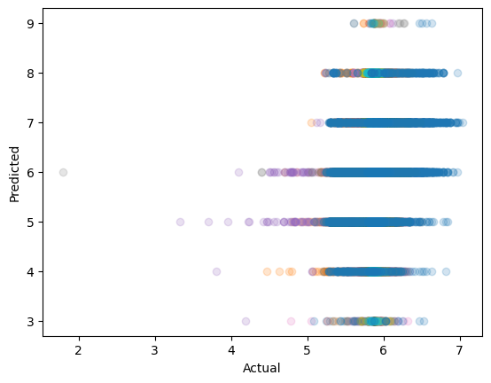

```python
mse_scores=[]
r2_score=[]
inputs=[]
mae_scores=[]

for c in x.columns:
    x_c = np.asarray(x[c])
    x_reshaped = np.reshape(x_c, (-1, 1))
    y=df['target']
    model=LinearRegression()
    model.fit(x_reshaped,y)
    y_pred= model.predict(x_reshaped)


    mse=mean_squared_error(y,y_pred)
    mse_scores.append(mse)


    score=model.score(x_reshaped,y)
    r2_score.append(score)

    mae = mean_absolute_error(y, y_pred)
    mae_scores.append(mae)

    inputs.append(c)

    plt.scatter(y_pred, y, alpha=.2)
    plt.xlabel('Actual')
    plt.ylabel('Predicted')

result_dict={
        "inputs": inputs,
        "MSE": mse_scores,
        "MAE": mae_scores,
       "R2": r2_score}
df_s=pd.DataFrame(result_dict)
df_s
```

The alcohol column performed the best out of all the inputs with MSE of .635, MAE of .627, and R2 of .189. The R2 would indicate that 19% of the variance in the wine quality is explained by the alcohol input, while 81% of the variance is unexplained. The column was the best performer out of the other columns but it did perform worst than the model in problem 5. It appears that the having the inputs in the model helped make the model more accurate and exluding them resulted in some bias in the coefficient of the variables which are used to predict the target variable.

### Problem 7 (20 points)

Pick and plot a pair of input columns with a visible dependency. Identify a split of the values of one column illustrating the dependency and plot histograms of the other variable on both sides of the split.

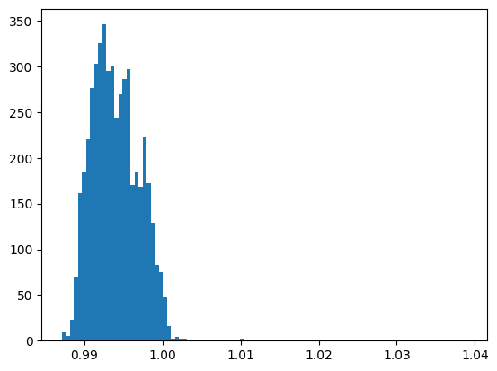

```python
#_=pd.plotting.scatter_matrix(df, alpha=0.4, figsize=(15, 15), diagonal='hist')# used to identify dependencies
_=df['density'].hist(grid=False, bins=100)
```

```
-70.90016689651206 0.0
```

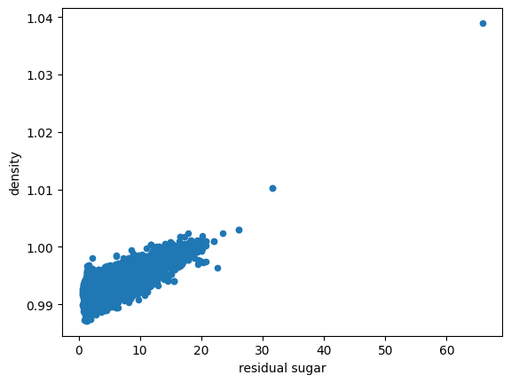

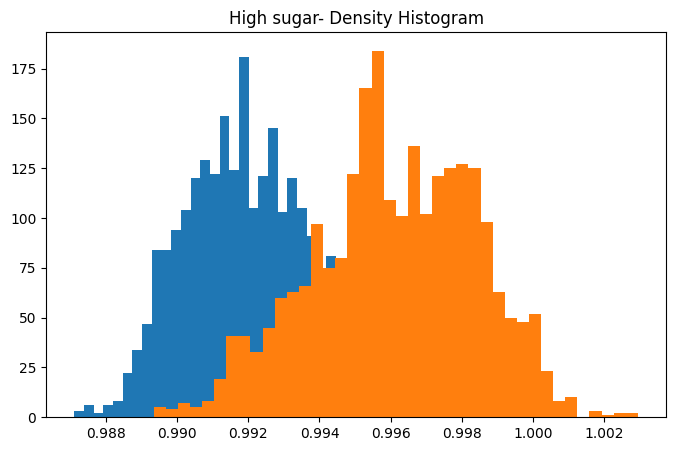

```python
_=df.plot.scatter( 'residual sugar','density',)# shows a dependancy
df_filtered= df[df['density']<1.01]# there seems to be an outlier and needed to filter it out

sugar_median = df['residual sugar'].median()

low_sugar = df_filtered[(df_filtered['residual sugar'] <= sugar_median)]
high_sugar = df_filtered[(df_filtered['residual sugar'] > sugar_median)]

plt.figure(figsize=(8,5))
plt.hist(low_sugar['density'], bins=40)
plt.title('Low sugar- Density Histogram')
#plt.subplot(1,2,2)
plt.hist(high_sugar['density'],bins=40)
plt.title('High sugar- Density Histogram')

# test difference in means using t-test
mean_low_sugar = low_sugar['density'].mean()
mean_high_sugar = high_sugar['density'].mean()
t_stat, p_value = scipy.stats.ttest_ind(low_sugar['density'], high_sugar['density'], equal_var=False)
print(t_stat, p_value)
```

From the histograms, low sugar wines are lower in density as the histogram shows that it is centered around .992(Blue). Looking at the high residual sugar wines, they are high in density with the center of the histogram being .996(orange). It is a small difference but increasing the number of bins does show a difference in means. Also, I desided to run a hypothesis test for the difference in means using a t-test. Null hypothesis being that the mean of the density from low sugar df is equal to teh mean of the density from high sugar df. The alternative hypothesis is that the means are not equal. The result suggest that we have to reject the null and that the means of the two samples are different from each other.(p-value=0.0)

### Problem 8 (40 points)

Perform principal components analysis of the input columns. Compute how much of the data variation is explained by the first half of the principal components. Build a linear regression using coordinates computed from the first half of the principal components. Compare the average training loss of this model to the previous model. Plot actual targets vs predictions again.

This problem depends on material from week 13.

```python
from sklearn.decomposition import PCA
df_pca=df.drop('target', axis=1)
normalized_wine= df_pca[df_pca.columns]/df_pca[df_pca.columns].std()
normalized_wine.describe()
wine_pca= PCA()
wine_pca.fit(normalized_wine)
wine_components= pd.DataFrame(wine_pca.components_, columns=df_pca.columns)


explained_variance_ratio = wine_pca.explained_variance_ratio_
explained_variance_ratio
half_components = len(explained_variance_ratio) // 2

cumulative_variance = np.sum(explained_variance_ratio[:half_components])
```

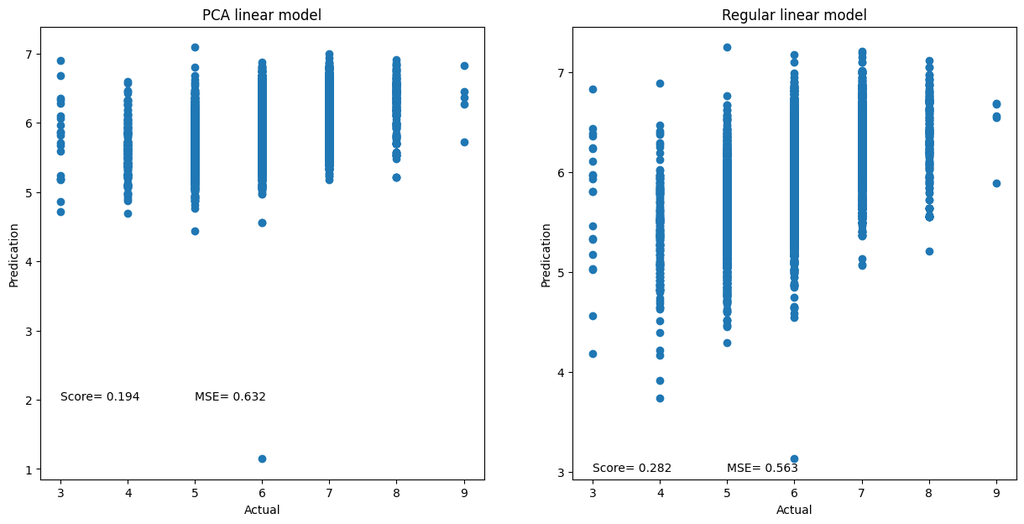

```python
from sklearn.linear_model import LinearRegression
from sklearn.metrics import mean_squared_error
x_pca= df[['density', 'total sulfur dioxide', 'free sulfur dioxide', 'residual sugar', 'chlorides', 'fixed acidity']]
y_pca=df['target']

model_pca= LinearRegression()
model_pca.fit(x_pca,y_pca)
y_pred_pca=model_pca.predict(x_pca)
mse_pca= mean_squared_error(y_pca, y_pred_pca)
score_pca = model_pca.score(x_pca, y_pca)

plt.figure(figsize=(15,7))
plt.subplot(1,2,1)
plt.scatter(y_pca, y_pred_pca)
plt.xlabel('Actual')
plt.ylabel('Predication')
plt.text(5,2, f"MSE= {round(mse_pca,3)}")
plt.text(3,2, f"Score= {round(score_pca,3)}")
plt.title("PCA linear model")


#Regular model using all inputs
x=df.drop('target', axis=1)
y=df['target']
model=LinearRegression()
model.fit(x,y)
y_pred=model.predict(x)
mse=mean_squared_error(y,y_pred)
score=model.score(x,y)

plt.subplot(1,2,2)
plt.scatter(y, y_pred)
plt.xlabel('Actual')
plt.ylabel('Predication')
plt.text(5,3, f"MSE= {round(mse,3)}")
plt.text(3,3, f"Score= {round(score,3)}")
plt.title("Regular linear model")
```

### Problem 9 (20 points)

What pair of input columns has the highest correlation? How is that correlation reflected in the principal components?

```python
round(df.corr(),3)
```

|  | fixed acidity | volatile acidity | citric acid | residual sugar | chlorides | free sulfur dioxide | total sulfur dioxide | density | pH | sulphates | alcohol | target |
| --- | --- | --- | --- | --- | --- | --- | --- | --- | --- | --- | --- | --- |
| fixed acidity | 1.000 | -0.023 | 0.289 | 0.089 | 0.023 | -0.049 | 0.091 | 0.265 | -0.426 | -0.017 | -0.121 | -0.114 |
| volatile acidity | -0.023 | 1.000 | -0.149 | 0.064 | 0.071 | -0.097 | 0.089 | 0.027 | -0.032 | -0.036 | 0.068 | -0.195 |
| citric acid | 0.289 | -0.149 | 1.000 | 0.094 | 0.114 | 0.094 | 0.121 | 0.150 | -0.164 | 0.062 | -0.076 | -0.009 |
| residual sugar | 0.089 | 0.064 | 0.094 | 1.000 | 0.089 | 0.299 | 0.401 | 0.839 | -0.194 | -0.027 | -0.451 | -0.098 |
| chlorides | 0.023 | 0.071 | 0.114 | 0.089 | 1.000 | 0.101 | 0.199 | 0.257 | -0.090 | 0.017 | -0.360 | -0.210 |
| free sulfur dioxide | -0.049 | -0.097 | 0.094 | 0.299 | 0.101 | 1.000 | 0.616 | 0.294 | -0.001 | 0.059 | -0.250 | 0.008 |
| total sulfur dioxide | 0.091 | 0.089 | 0.121 | 0.401 | 0.199 | 0.616 | 1.000 | 0.530 | 0.002 | 0.135 | -0.449 | -0.175 |
| density | 0.265 | 0.027 | 0.150 | 0.839 | 0.257 | 0.294 | 0.530 | 1.000 | -0.094 | 0.074 | -0.780 | -0.307 |
| pH | -0.426 | -0.032 | -0.164 | -0.194 | -0.090 | -0.001 | 0.002 | -0.094 | 1.000 | 0.156 | 0.121 | 0.099 |
| sulphates | -0.017 | -0.036 | 0.062 | -0.027 | 0.017 | 0.059 | 0.135 | 0.074 | 0.156 | 1.000 | -0.017 | 0.054 |
| alcohol | -0.121 | 0.068 | -0.076 | -0.451 | -0.360 | -0.250 | -0.449 | -0.780 | 0.121 | -0.017 | 1.000 | 0.436 |
| target | -0.114 | -0.195 | -0.009 | -0.098 | -0.210 | 0.008 | -0.175 | -0.307 | 0.099 | 0.054 | 0.436 | 1.000 |

### Problem 10 (30 points)

Identify an outlier row in the data set. You may use any criteria you like, but you must explain the criteria and how it led to picking this row. Give a visualization showing how much this row sticks out compared to the other data based on your criteria.

```python
from sklearn.preprocessing import StandardScaler
#standardizing the data by using z_scores
df_scaled=df.copy()
scaler = StandardScaler()

df_scaled = scaler.fit_transform(df)

# Convert the result back to a DataFrame
df_scaled = pd.DataFrame(df_scaled, columns=df.columns)
round(df_scaled.describe(),2)
```

|  | fixed acidity | volatile acidity | citric acid | residual sugar | chlorides | free sulfur dioxide | total sulfur dioxide | density | pH | sulphates | alcohol | target |
| --- | --- | --- | --- | --- | --- | --- | --- | --- | --- | --- | --- | --- |
| count | 4898.00 | 4898.00 | 4898.00 | 4898.00 | 4898.00 | 4898.00 | 4898.00 | 4898.00 | 4898.00 | 4898.00 | 4898.00 | 4898.00 |
| mean | -0.00 | 0.00 | 0.00 | -0.00 | 0.00 | -0.00 | -0.00 | 0.00 | -0.00 | -0.00 | -0.00 | 0.00 |
| std | 1.00 | 1.00 | 1.00 | 1.00 | 1.00 | 1.00 | 1.00 | 1.00 | 1.00 | 1.00 | 1.00 | 1.00 |
| min | -3.62 | -1.97 | -2.76 | -1.14 | -1.68 | -1.96 | -3.04 | -2.31 | -3.10 | -2.36 | -2.04 | -3.25 |
| 25% | -0.66 | -0.68 | -0.53 | -0.93 | -0.45 | -0.72 | -0.71 | -0.77 | -0.65 | -0.70 | -0.82 | -0.99 |
| 50% | -0.06 | -0.18 | -0.12 | -0.23 | -0.13 | -0.08 | -0.10 | -0.10 | -0.05 | -0.17 | -0.09 | 0.14 |
| 75% | 0.53 | 0.41 | 0.46 | 0.69 | 0.19 | 0.63 | 0.67 | 0.69 | 0.61 | 0.53 | 0.72 | 0.14 |
| max | 8.71 | 8.15 | 10.96 | 11.71 | 13.74 | 14.92 | 7.10 | 15.03 | 4.18 | 5.17 | 3.00 | 3.53 |

```python
rows_greater_than_3 = df_scaled.apply(lambda row: (row > 4).sum() >= 3, axis=1) # I altered (row>4) and >=3 to find extreme values.

# Filter the rows where the condition is met
filtered_rows = df_scaled[rows_greater_than_3]

filtered_rows
```

|  | fixed acidity | volatile acidity | citric acid | residual sugar | chlorides | free sulfur dioxide | total sulfur dioxide | density | pH | sulphates | alcohol | target |
| --- | --- | --- | --- | --- | --- | --- | --- | --- | --- | --- | --- | --- |
| 2781 | 1.120209 | 6.814148 | 2.196629 | 11.714112 | 1.292135 | -1.605848 | 0.509236 | 15.031298 | 1.336114 | 1.753972 | 0.963623 | 0.13787 |

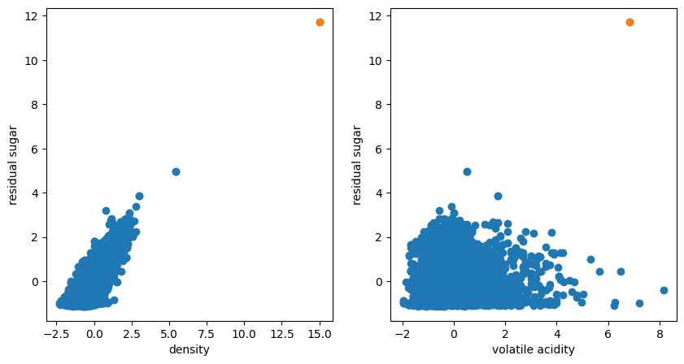

```python
plt.figure(figsize=(10,5))
plt.subplot(1,2,1)
plt.scatter(df_scaled['density'],df_scaled['residual sugar'])
plt.scatter(filtered_rows['density'], filtered_rows['residual sugar'])
plt.xlabel('density')
plt.ylabel('residual sugar')

plt.subplot(1,2,2)
plt.scatter(df_scaled['volatile acidity'],df_scaled['residual sugar'])
plt.scatter(filtered_rows['volatile acidity'], filtered_rows['residual sugar'])
plt.xlabel('volatile acidity')
plt.ylabel('residual sugar')
```

The first step to find an outlier row was to standardize the data to make it easier to spot any ouliers. Z scores are a way to measure how far away a data point is from the mean. Usually, z scores that are greater than 3 or less than -3 would be a good metric to identify outliers because 99.73 percent of the data lies within 3 standard deviations form the mean and any point over the threshold is less likely to occur. This method led me to find row that had a least one columns with a value grater than 3. There were many rows that met that criteria which lead me to incease the contraint to at least 3 columns and then increase the z score value to be over 4. The process lead me to get the filtered_rows results and ploted two scatter plot to show the outliers (orange)..

```python
import subprocess

# Define the notebook filename
notebook_filename = "final1.ipynb"

# Convert the notebook to PDF
subprocess.run([
    "jupyter", "nbconvert",
    "--to", "pdf",
    notebook_filename
])
```

[output not shown]

[output cut: 132 more lines]

[output not shown]

[output not shown]

[output not shown]